# JMAK_for_thesis

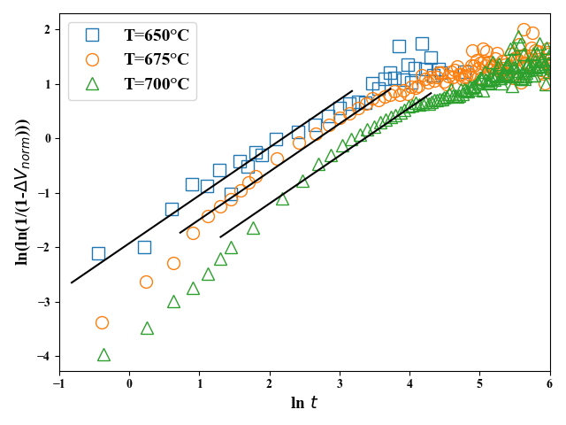

```python
x1 = np.arange(lnt1_10, lnt1_90, 0.5)
x2 = np.arange(lnt2_10, lnt2_90, 0.5)
x3 = np.arange(lnt3_10, lnt3_90, 0.5)

n = 3
fig, ax = plt.subplots()
plt.rcParams["font.family"] = "Times New Roman"
ax.plot(lume_1_JMAK['lnt'][::n], lume_1_JMAK['product'][::n], 's', fillstyle='none', markersize=10, label = 'T=650°C')
ax.plot(lume_2_JMAK['lnt'][::n], lume_2_JMAK['product'][::n], 'o', fillstyle='none', markersize=10, label = 'T=675°C')
ax.plot(lume_3_JMAK['lnt'][::n], lume_3_JMAK['product'][::n], '^', fillstyle='none', markersize=10, label = 'T=700°C')
ax.plot(x1, x1*n_ave + fit1[1],'-', color='black')
ax.plot(x2, x2*n_ave + fit2[1],'-', color='black')
ax.plot(x3, x3*n_ave + fit3[1],'-', color='black')
ax.set_xlabel(r'ln$\ t$', fontname='Times New Roman',fontsize=14)
ax.set_ylabel('ln(ln(1/(1-$\Delta V_{norm}$)))', fontname='Times New Roman',fontsize=14)
ax.axis(xmin=-1, xmax=6)
plt.legend(fontsize=14)
plt.tight_layout()
plt.show()
```

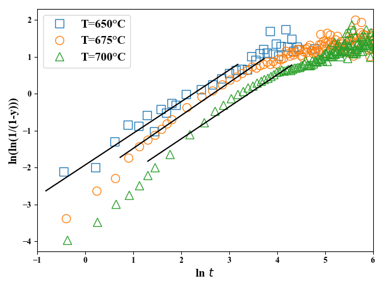

```python
x1 = np.arange(lnt1_10, lnt1_90, 0.5)
x2 = np.arange(lnt2_10, lnt2_90, 0.5)
x3 = np.arange(lnt3_10, lnt3_90, 0.5)

n = 3
fig, ax = plt.subplots()
plt.rcParams["font.family"] = "Times New Roman"
ax.plot(lume_1_JMAK['lnt'][::n], lume_1_JMAK['product'][::n], 's', fillstyle='none', markersize=10, label = 'T=650°C')
ax.plot(lume_2_JMAK['lnt'][::n], lume_2_JMAK['product'][::n], 'o', fillstyle='none', markersize=10, label = 'T=675°C')
ax.plot(lume_3_JMAK['lnt'][::n], lume_3_JMAK['product'][::n], '^', fillstyle='none', markersize=10, label = 'T=700°C')
ax.plot(x1, x1*fit1[0] + fit1[1],'-', color='black')
ax.plot(x2, x2*fit2[0] + fit2[1],'-', color='black')
ax.plot(x3, x3*fit3[0] + fit3[1],'-', color='black')
ax.set_xlabel(r'ln$\ t$', fontname='Times New Roman',fontsize=14)
ax.set_ylabel('ln(ln(1/(1-y)))', fontname='Times New Roman',fontsize=14)
ax.axis(xmin=-1, xmax=6)
plt.legend(fontsize=14)
plt.tight_layout()
plt.show()
```

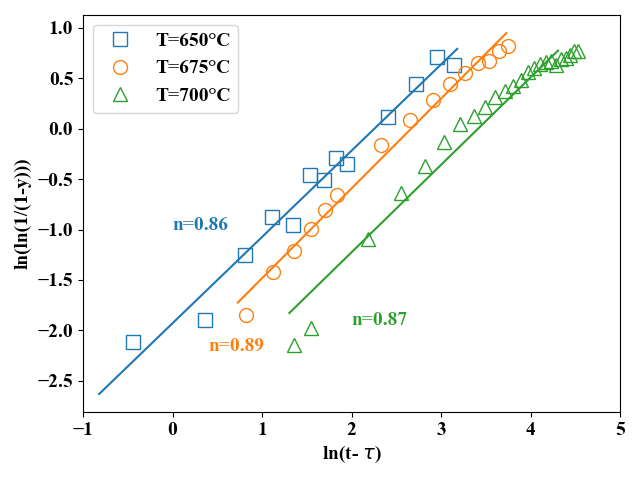

```python
x1 = np.arange(lnt1_10, lnt1_90, 0.5)
x2 = np.arange(lnt2_10, lnt2_90, 0.5)
x3 = np.arange(lnt3_10, lnt3_90, 0.5)

lume_1_JMAK20Mn = lume_1_JMAK[(lume_1_JMAK['lnt']>lnt1_10)&(lume_1_JMAK['lnt']<lnt1_90)]
lume_2_JMAK20Mn = lume_2_JMAK[(lume_2_JMAK['lnt']>lnt2_10)&(lume_2_JMAK['lnt']<lnt2_90)]
lume_3_JMAK20Mn = lume_3_JMAK[(lume_3_JMAK['lnt']>lnt3_10)&(lume_3_JMAK['lnt']<lnt3_90)]

n1 = 4
fig, ax = plt.subplots()
plt.rcParams["font.family"] = "Times New Roman"
ax.plot(lume_1_JMAK20Mn['lnt'][::n1], lume_1_JMAK20Mn['product'][::n1], 's', fillstyle='none', markersize=10,label = 'T=650°C')
ax.plot(lume_2_JMAK20Mn['lnt'][::n1], lume_2_JMAK20Mn['product'][::n1], 'o', fillstyle='none', markersize=10, label = 'T=675°C')
ax.plot(lume_3_JMAK20Mn['lnt'][::n1], lume_3_JMAK20Mn['product'][::n1], '^', fillstyle='none', markersize=10, label = 'T=700°C')
ax.plot(x1, x1*fit1[0] + fit1[1],'-', color='C0')
ax.plot(x2, x2*fit2[0] + fit2[1],'-', color='C1')
ax.plot(x3, x3*fit3[0] + fit3[1],'-', color='C2')
ax.text(x=0, y=-1.0,s='n=0.86',color='C0', fontsize=14)
ax.text(x=0.4, y=-2.2,s='n=0.89',color='C1', fontsize=14)
ax.text(x=2, y=-1.95,s='n=0.87',color='C2', fontsize=14)


ax.set_xlabel(r'ln(t- $\tau$)', fontname='Times New Roman',fontsize=14)
ax.set_ylabel('ln(ln(1/(1-y)))', fontname='Times New Roman',fontsize=14)
ax.axis(xmin=-1, xmax=5)
plt.yticks(fontname='Times New Roman', fontsize=14)
plt.xticks(fontname='Times New Roman', fontsize=14)
plt.legend(fontsize=14)
plt.tight_layout()
#plt.show()
os.chdir(figd)
plt.savefig('JMAK_logplot_20Mn.tiff', dpi=300)
os.chdir(startwd)
```

In terms of the intercept on the above fitting, this values can be considered as temperature dependent. The following plot gives the fitting the relationship between the rate parameter and the temperature in Kelvin.

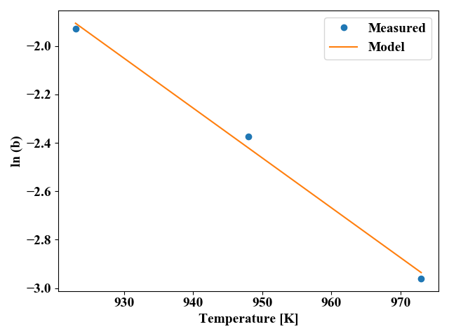

```python
lnb = [fit1[1], fit2[1], fit3[1]]
Temp = [650+273, 675+273, 700+273]
fit_lnb = np.polyfit(x=Temp, y=lnb, deg =1)
lnb_model = fit_lnb[0]*np.array(Temp) + fit_lnb[1]
fig, ax = plt.subplots()
plt.rcParams["font.family"] = "Times New Roman"
ax.plot(Temp, lnb, 'o', label ='Measured')
ax.plot(Temp, lnb_model, '-', label = 'Model')
ax.set_xlabel('Temperature [K]', fontname='Times New Roman',fontsize=14)
ax.set_ylabel('ln (b)', fontname='Times New Roman',fontsize=14)
plt.yticks(fontname='Times New Roman', fontsize=14)
plt.xticks(fontname='Times New Roman', fontsize=14)
plt.legend(fontsize=14)
plt.tight_layout()
plt.show()
```

```python
lnb20Mn = [fit1[1], fit2[1], fit3[1]]
Temp20Mn = [650+273, 675+273, 700+273]
fit_lnb20Mn = np.polyfit(x=Temp, y=lnb, deg =1)
lnb_model20Mn = fit_lnb20Mn[0]*np.array(Temp20Mn) + fit_lnb20Mn[1]
```

```python
b_model = np.e**lnb_model
b_model
```

```
array([0.14869477, 0.08884232, 0.05308161])
```

```python
fit_lnb
```

```
array([-0.0206013 , 17.10914475])
```

To take acount for the temperature dependency of the intercept of the JMAK plot (the natural logarithm of the rate parameter), the liniear fitting can be applied. The obtained relations can be expressed as follows. $$ ln(b) = -0.0206(\frac{1}{K})T(K) + 17.109 $$ By using the above relationship, the JMAK model is applied to the normalized fraction for each condition. $$ X_{i,norm} = 1 - exp(-b_{i}t^n)$$ where i corresponds to each temperature condition. More specifically, $$ X_{650,norm} = 1 - exp(-0.149t^{0.88})$$ $$ X_{675,norm} = 1 - exp(-0.089t^{0.88})$$ $$ X_{700,norm} = 1 - exp(-0.053t^{0.88})$$

The following code compares the JMAK fitting for the normalized fraction transformed with the measurement.

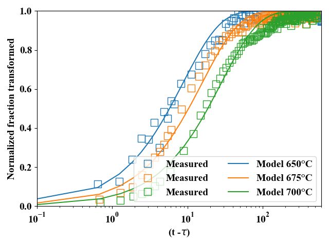

```python
b_model = np.e**lnb_model
lume_1['JMAK'] = 1- np.exp(-b_model[0]*lume_1['Time']**n_ave)
lume_2['JMAK'] = 1- np.exp(-b_model[1]*lume_2['Time']**n_ave)
lume_3['JMAK'] = 1- np.exp(-b_model[2]*lume_3['Time']**n_ave)

nn = 3
fig, ax = plt.subplots()
plt.rcParams["font.family"] = "Times New Roman"
ax.semilogx(lume_1['Time'][::nn], lume_1['dv_norm'][::nn], 's', fillstyle='none', markersize=10,color='C0', label='Measured')
ax.semilogx(lume_2['Time'][::nn], lume_2['dv_norm'][::nn], 's', fillstyle='none', markersize=10, color='C1', label='Measured')
ax.semilogx(lume_3['Time'][::nn], lume_3['dv_norm'][::nn], 's', fillstyle='none', markersize=10, color='C2', label='Measured')
ax.semilogx(lume_1['Time'][::nn], lume_1['JMAK'][::nn], '-',  color='C0', label='Model 650°C')
ax.semilogx(lume_2['Time'][::nn], lume_2['JMAK'][::nn], '-',  color='C1', label='Model 675°C')
ax.semilogx(lume_3['Time'][::nn], lume_3['JMAK'][::nn], '-',  color='C2', label='Model 700°C')
ax.axis(xmin =0.1, xmax=600, ymin=0, ymax=1)
ax.set_xlabel(r'(t -$\tau$)', fontname='Times New Roman',fontsize=14)
ax.set_ylabel('Normalized fraction transformed', fontname='Times New Roman',fontsize=14)
plt.yticks(fontname='Times New Roman', fontsize=14)
plt.xticks(fontname='Times New Roman', fontsize=14)
plt.legend(fontsize=14,ncol=2)
plt.tight_layout()
#plt.show()
os.chdir(figd)
plt.savefig('Comparison_JMAK_20Mn.tiff', dpi=300)
os.chdir(startwd)
```

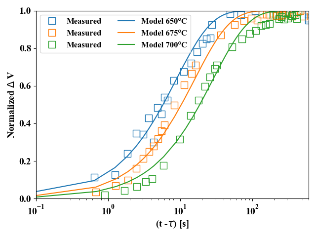

```python
def sparse_lume(lume, n1=3, n2=20,threshold=0.7):
    lume1 = lume[lume['dv_norm']<threshold]
    lume2 = lume[lume['dv_norm']>=threshold]
    lume1 = lume1[::n1]
    lume2 = lume2[::n2]
    lume3 = pd.concat([lume1, lume2])
    return lume3

lume_1s = sparse_lume(lume_1,threshold=0.9)
lume_2s = sparse_lume(lume_2)
lume_3s = sparse_lume(lume_3,n1=4)

nn = 3
fig, ax = plt.subplots()
plt.rcParams["font.family"] = "Times New Roman"
ax.semilogx(lume_1s['Time'], lume_1s['dv_norm'], 's', fillstyle='none', markersize=10,color='C0', label='Measured')
ax.semilogx(lume_2s['Time'], lume_2s['dv_norm'], 's', fillstyle='none', markersize=10, color='C1', label='Measured')
ax.semilogx(lume_3s['Time'], lume_3s['dv_norm'], 's', fillstyle='none', markersize=10, color='C2', label='Measured')
ax.semilogx(lume_1['Time'][::nn], lume_1['JMAK'][::nn], '-',  color='C0', label='Model 650°C')
ax.semilogx(lume_2['Time'][::nn], lume_2['JMAK'][::nn], '-',  color='C1', label='Model 675°C')
ax.semilogx(lume_3['Time'][::nn], lume_3['JMAK'][::nn], '-',  color='C2', label='Model 700°C')
ax.axis(xmin =0.1, xmax=600, ymin=0, ymax=1)
ax.set_xlabel(r'(t -$\tau$) [s]', fontname='Times New Roman',fontsize=14)
ax.set_ylabel(r'Normalized $ \Delta$ V', fontname='Times New Roman',fontsize=14)
plt.yticks(fontname='Times New Roman', fontsize=14)
plt.xticks(fontname='Times New Roman', fontsize=14)
plt.legend(fontsize=12,ncol=2)
plt.tight_layout()
#plt.show()
os.chdir(figd)
plt.savefig('Comparison_JMAK_20Mn2.tiff', dpi=300)
os.chdir(startwd)
```